# A. J. Stewart Lange R workshops

Lee Mercer

02/09/2021

## Workshop 2 ——————————————————————

### Your first R script

```r
library(see)
library(tidyverse) # load the tidyverse
library(ggrepel)
library(patchwork) # needed to combine our 4 plots at the end
```

### Read in data

```r
ufo_sightings <- read_csv("https://raw.githubusercontent.com/rfordatascience/tidytuesday/master/data/2019/2019-06-25/ufo_sightings.csv")
```

### Plot of top 10 US states with number of sightings in each state

```r
plot1 <- ufo_sightings %>%
  filter(!is.na(state)) %>%
  mutate(state = str_to_upper(state)) %>%
  group_by(state) %>%
  tally() %>%
  top_n(10) %>%
  ggplot(aes(x = reorder(state, n), y = n, fill = state)) +
  geom_col() +
  coord_flip() +
  guides(fill = FALSE) +
  labs(title = "Top 10 States for UFO Sightings",
       x = NULL,
       y = NULL) +
  ylim(0, 11000) +
  theme_minimal() +
  theme(text = element_text(size = 15))
```

### Work out the top 10 states with most UFO sightings

```r
top_states <- ufo_sightings %>%
  filter(!is.na(state)) %>%
  group_by(state) %>%
  tally() %>%
  top_n(10) %>%
  pull(state)
```

### Work out states within lat and long limits (i.e., exclude Alaska)

```r
tidied_ufo <- ufo_sightings %>%
  filter(country == "us") %>%
  filter(latitude > 24 & latitude < 50)
```

```r
plot2 <- tidied_ufo %>%
  ggplot(aes(x = longitude, y = latitude)) +
  geom_point(size = .5, alpha = .25) +
  theme_void() +
  coord_cartesian() +
  labs(title = "Sites of UFO Sightings in the US") +
  guides(colour = FALSE) +
  guides(fill = FALSE) +
  theme(text = element_text(size = 15))
```

### Plot of top 10 UFO shapes spotted in California

```r
plot3 <- tidied_ufo %>%
  filter(state == "ca") %>%
  filter(ufo_shape != "other") %>%
  filter(ufo_shape != "unknown") %>%
  group_by(ufo_shape) %>%
  tally() %>%
  top_n(10) %>%
  mutate(ufo_shape = str_to_title(ufo_shape)) %>%
  ggplot(aes(x = reorder(ufo_shape, n), y = n, fill = ufo_shape)) +
  geom_col() +
  coord_flip() +
  guides(fill = FALSE) +
  labs(title = "Top 10 UFO Shapes spotted in California",
       x = NULL,
       y = NULL) +
  theme_minimal() +
  theme(text = element_text(size = 15))
```

### Put plots together

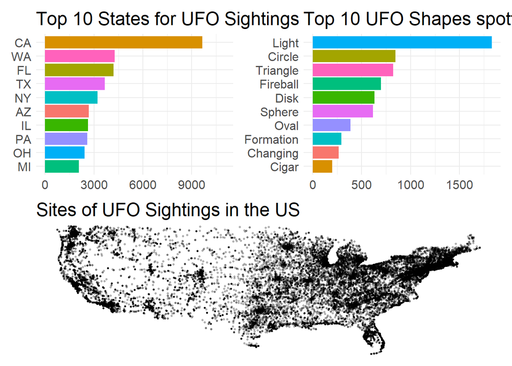

```r
my_plot <- (plot1 + plot3) / (plot2)
ggsave("ufo_plot.jpg", plot = my_plot, width = 12, height = 10)
my_plot
```

## Workshop 3 ——————————————————————

### Data wrangling

```r
library(tidyverse)

head(mpg,10)
```

```
## # A tibble: 10 x 11
##    manufacturer model      displ  year   cyl trans drv     cty   hwy fl    class
##    <chr>        <chr>      <dbl> <int> <int> <chr> <chr> <int> <int> <chr> <chr>
##  1 audi         a4           1.8  1999     4 auto~ f        18    29 p     comp~
##  2 audi         a4           1.8  1999     4 manu~ f        21    29 p     comp~
##  3 audi         a4           2    2008     4 manu~ f        20    31 p     comp~
##  4 audi         a4           2    2008     4 auto~ f        21    30 p     comp~
##  5 audi         a4           2.8  1999     6 auto~ f        16    26 p     comp~
##  6 audi         a4           2.8  1999     6 manu~ f        18    26 p     comp~
##  7 audi         a4           3.1  2008     6 auto~ f        18    27 p     comp~
##  8 audi         a4 quattro   1.8  1999     4 manu~ 4        18    26 p     comp~
##  9 audi         a4 quattro   1.8  1999     4 auto~ 4        16    25 p     comp~
## 10 audi         a4 quattro   2    2008     4 manu~ 4        20    28 p     comp~
```

```r
str(mpg)
```

```
## tibble [234 x 11] (S3: tbl_df/tbl/data.frame)
##  $ manufacturer: chr [1:234] "audi" "audi" "audi" "audi" ...
##  $ model       : chr [1:234] "a4" "a4" "a4" "a4" ...
##  $ displ       : num [1:234] 1.8 1.8 2 2 2.8 2.8 3.1 1.8 1.8 2 ...
##  $ year        : int [1:234] 1999 1999 2008 2008 1999 1999 2008 1999 1999 2008 ...
##  $ cyl         : int [1:234] 4 4 4 4 6 6 6 4 4 4 ...
##  $ trans       : chr [1:234] "auto(l5)" "manual(m5)" "manual(m6)" "auto(av)" ...
##  $ drv         : chr [1:234] "f" "f" "f" "f" ...
##  $ cty         : int [1:234] 18 21 20 21 16 18 18 18 16 20 ...
##  $ hwy         : int [1:234] 29 29 31 30 26 26 27 26 25 28 ...
##  $ fl          : chr [1:234] "p" "p" "p" "p" ...
##  $ class       : chr [1:234] "compact" "compact" "compact" "compact" ...
```

```r
mpg %>%
  select(manufacturer)
```

```
## # A tibble: 234 x 1
##    manufacturer
##    <chr>
##  1 audi
##  2 audi
##  3 audi
##  4 audi
##  5 audi
##  6 audi
##  7 audi
##  8 audi
##  9 audi
## 10 audi
## # ... with 224 more rows
```

```r
mpg %>%
  distinct(manufacturer) %>%  #Identifies unique entries
  count()                     #Counts unique entries
```

```
## # A tibble: 1 x 1
##       n
##   <int>
## 1    15
```

```r
mpg %>%
  filter(manufacturer == "honda") #Extracts all 'Honda' entries
```

```
## # A tibble: 9 x 11
##   manufacturer model displ  year   cyl trans      drv     cty   hwy fl    class
##   <chr>        <chr> <dbl> <int> <int> <chr>      <chr> <int> <int> <chr> <chr>
## 1 honda        civic   1.6  1999     4 manual(m5) f        28    33 r     subco~
## 2 honda        civic   1.6  1999     4 auto(l4)   f        24    32 r     subco~
## 3 honda        civic   1.6  1999     4 manual(m5) f        25    32 r     subco~
## 4 honda        civic   1.6  1999     4 manual(m5) f        23    29 p     subco~
## 5 honda        civic   1.6  1999     4 auto(l4)   f        24    32 r     subco~
## 6 honda        civic   1.8  2008     4 manual(m5) f        26    34 r     subco~
## 7 honda        civic   1.8  2008     4 auto(l5)   f        25    36 r     subco~
## 8 honda        civic   1.8  2008     4 auto(l5)   f        24    36 c     subco~
## 9 honda        civic   2    2008     4 manual(m6) f        21    29 p     subco~
```

```r
mpg %>%
  filter(manufacturer == "honda" | manufacturer == "audi")  # | = 'or'
```

```
## # A tibble: 27 x 11
##    manufacturer model      displ  year   cyl trans drv     cty   hwy fl    class
##    <chr>        <chr>      <dbl> <int> <int> <chr> <chr> <int> <int> <chr> <chr>
##  1 audi         a4           1.8  1999     4 auto~ f        18    29 p     comp~
##  2 audi         a4           1.8  1999     4 manu~ f        21    29 p     comp~
##  3 audi         a4           2    2008     4 manu~ f        20    31 p     comp~
##  4 audi         a4           2    2008     4 auto~ f        21    30 p     comp~
##  5 audi         a4           2.8  1999     6 auto~ f        16    26 p     comp~
##  6 audi         a4           2.8  1999     6 manu~ f        18    26 p     comp~
##  7 audi         a4           3.1  2008     6 auto~ f        18    27 p     comp~
##  8 audi         a4 quattro   1.8  1999     4 manu~ 4        18    26 p     comp~
##  9 audi         a4 quattro   1.8  1999     4 auto~ 4        16    25 p     comp~
## 10 audi         a4 quattro   2    2008     4 manu~ 4        20    28 p     comp~
## # ... with 17 more rows
```

```r
mpg %>%
  filter(manufacturer == "honda" & year == "1999") %>%
  select(manufacturer, year, cty, hwy)
```

```
## # A tibble: 5 x 4
##   manufacturer  year   cty   hwy
##   <chr>        <int> <int> <int>
## 1 honda         1999    28    33
## 2 honda         1999    24    32
## 3 honda         1999    25    32
## 4 honda         1999    23    29
## 5 honda         1999    24    32
```

```r
mpg %>%
  mutate(manufacturer = str_to_title(manufacturer),
         model = str_to_title(model)) %>%
  select(manufacturer, model, year, trans, hwy)
```

```
## # A tibble: 234 x 5
##    manufacturer model       year trans        hwy
##    <chr>        <chr>      <int> <chr>      <int>
##  1 Audi         A4          1999 auto(l5)      29
##  2 Audi         A4          1999 manual(m5)    29
##  3 Audi         A4          2008 manual(m6)    31
##  4 Audi         A4          2008 auto(av)      30
##  5 Audi         A4          1999 auto(l5)      26
##  6 Audi         A4          1999 manual(m5)    26
##  7 Audi         A4          2008 auto(av)      27
##  8 Audi         A4 Quattro  1999 manual(m5)    26
##  9 Audi         A4 Quattro  1999 auto(l5)      25
## 10 Audi         A4 Quattro  2008 manual(m6)    28
## # ... with 224 more rows
```

```r
my_messy_data <- read_csv("https://raw.githubusercontent.com/ajstewartlang/03_data_wrangling/master/data/my_data.csv")

head(my_messy_data)
```

```
## # A tibble: 6 x 3
##   participant condition    rt
##         <dbl>     <dbl> <dbl>
## 1           1         1   879
## 2           1         2  1027
## 3           1         3  1108
## 4           1         4   765
## 5           2         1  1042
## 6           2         2  1050
```

```r
my_tidied_data <- my_messy_data %>%
  mutate(condition = recode(condition,
                            "1" = "PrimeA_TargetA",
                            "2" = "PrimeA_TargetB",
                            "3" = "PrimeB_TargetA",
                            "4" = "PrimeB_TargetB")) %>%
  separate(col = "condition", into = c("Prime", "Target"), sep = "_") %>%
  mutate(Prime = factor(Prime), Target = factor(Target))
```

### Data summarizing

```r
library(tidyverse)

mpg %>%
  group_by(manufacturer) %>%
  summarise(mean_hwy = mean(hwy), sd_hwy = sd(hwy), number = n()) %>%
  arrange(-mean_hwy)
```

```
## # A tibble: 15 x 4
##    manufacturer mean_hwy sd_hwy number
##    <chr>           <dbl>  <dbl>  <int>
##  1 honda            32.6   2.55      9
##  2 volkswagen       29.2   5.32     27
##  3 hyundai          26.9   2.18     14
##  4 audi             26.4   2.18     18
##  5 pontiac          26.4   1.14      5
##  6 subaru           25.6   1.16     14
##  7 toyota           24.9   6.17     34
##  8 nissan           24.6   5.09     13
##  9 chevrolet        21.9   5.11     19
## 10 ford             19.4   3.33     25
## 11 mercury          18     1.15      4
## 12 dodge            17.9   3.57     37
## 13 jeep             17.6   3.25      8
## 14 lincoln          17     1         3
## 15 land rover       16.5   1.73      4
```

```r
mpg %>%
  group_by(manufacturer) %>%
  summarise_at(c("displ", "cty", "hwy"), mean, na.rm = T)
```

```
## # A tibble: 15 x 4
##    manufacturer displ   cty   hwy
##    <chr>        <dbl> <dbl> <dbl>
##  1 audi          2.54  17.6  26.4
##  2 chevrolet     5.06  15    21.9
##  3 dodge         4.38  13.1  17.9
##  4 ford          4.54  14    19.4
##  5 honda         1.71  24.4  32.6
##  6 hyundai       2.43  18.6  26.9
##  7 jeep          4.58  13.5  17.6
##  8 land rover    4.3   11.5  16.5
##  9 lincoln       5.4   11.3  17
## 10 mercury       4.4   13.2  18
## 11 nissan        3.27  18.1  24.6
## 12 pontiac       3.96  17    26.4
## 13 subaru        2.46  19.3  25.6
## 14 toyota        2.95  18.5  24.9
## 15 volkswagen    2.26  20.9  29.2
```

```r
mpg %>%
  group_by(manufacturer) %>%
  summarise_if(is.numeric, mean, na.rm = T)
```

```
## # A tibble: 15 x 6
##    manufacturer displ  year   cyl   cty   hwy
##    <chr>        <dbl> <dbl> <dbl> <dbl> <dbl>
##  1 audi          2.54 2004.  5.22  17.6  26.4
##  2 chevrolet     5.06 2005.  7.26  15    21.9
##  3 dodge         4.38 2004.  7.08  13.1  17.9
##  4 ford          4.54 2003.  7.2   14    19.4
##  5 honda         1.71 2003   4     24.4  32.6
##  6 hyundai       2.43 2004.  4.86  18.6  26.9
##  7 jeep          4.58 2006.  7.25  13.5  17.6
##  8 land rover    4.3  2004.  8     11.5  16.5
##  9 lincoln       5.4  2002   8     11.3  17
## 10 mercury       4.4  2004.  7     13.2  18
## 11 nissan        3.27 2004.  5.54  18.1  24.6
## 12 pontiac       3.96 2003.  6.4   17    26.4
## 13 subaru        2.46 2004.  4     19.3  25.6
## 14 toyota        2.95 2003.  5.12  18.5  24.9
## 15 volkswagen    2.26 2003.  4.59  20.9  29.2
```

```r
mpg %>%
  group_by(manufacturer) %>%
  mutate(mean_hwy = mean(hwy), sd_hwy = sd(hwy)) %>%
  select(-class, -trans)
```

```
## # A tibble: 234 x 11
## # Groups:   manufacturer [15]
##    manufacturer model  displ  year   cyl drv     cty   hwy fl    mean_hwy sd_hwy
##    <chr>        <chr>  <dbl> <int> <int> <chr> <int> <int> <chr>    <dbl>  <dbl>
##  1 audi         a4       1.8  1999     4 f        18    29 p         26.4   2.18
##  2 audi         a4       1.8  1999     4 f        21    29 p         26.4   2.18
##  3 audi         a4       2    2008     4 f        20    31 p         26.4   2.18
##  4 audi         a4       2    2008     4 f        21    30 p         26.4   2.18
##  5 audi         a4       2.8  1999     6 f        16    26 p         26.4   2.18
##  6 audi         a4       2.8  1999     6 f        18    26 p         26.4   2.18
##  7 audi         a4       3.1  2008     6 f        18    27 p         26.4   2.18
##  8 audi         a4 qu~   1.8  1999     4 4        18    26 p         26.4   2.18
##  9 audi         a4 qu~   1.8  1999     4 4        16    25 p         26.4   2.18
## 10 audi         a4 qu~   2    2008     4 4        20    28 p         26.4   2.18
## # ... with 224 more rows
```

```r
mpg_with_mean <- mpg %>%
  group_by(manufacturer) %>%
  mutate(mean_hwy = mean(hwy), sd_hwy = sd(hwy)) %>%
  select(-class, -trans)

head(mpg_with_mean)
```

```
## # A tibble: 6 x 11
## # Groups:   manufacturer [1]
##   manufacturer model displ  year   cyl drv     cty   hwy fl    mean_hwy sd_hwy
##   <chr>        <chr> <dbl> <int> <int> <chr> <int> <int> <chr>    <dbl>  <dbl>
## 1 audi         a4      1.8  1999     4 f        18    29 p         26.4   2.18
## 2 audi         a4      1.8  1999     4 f        21    29 p         26.4   2.18
## 3 audi         a4      2    2008     4 f        20    31 p         26.4   2.18
## 4 audi         a4      2    2008     4 f        21    30 p         26.4   2.18
## 5 audi         a4      2.8  1999     6 f        16    26 p         26.4   2.18
## 6 audi         a4      2.8  1999     6 f        18    26 p         26.4   2.18
```

```r
str(mpg_with_mean)
```

```
## grouped_df [234 x 11] (S3: grouped_df/tbl_df/tbl/data.frame)
##  $ manufacturer: chr [1:234] "audi" "audi" "audi" "audi" ...
##  $ model       : chr [1:234] "a4" "a4" "a4" "a4" ...
##  $ displ       : num [1:234] 1.8 1.8 2 2 2.8 2.8 3.1 1.8 1.8 2 ...
##  $ year        : int [1:234] 1999 1999 2008 2008 1999 1999 2008 1999 1999 2008 ...
##  $ cyl         : int [1:234] 4 4 4 4 6 6 6 4 4 4 ...
##  $ drv         : chr [1:234] "f" "f" "f" "f" ...
##  $ cty         : int [1:234] 18 21 20 21 16 18 18 18 16 20 ...
##  $ hwy         : int [1:234] 29 29 31 30 26 26 27 26 25 28 ...
##  $ fl          : chr [1:234] "p" "p" "p" "p" ...
##  $ mean_hwy    : num [1:234] 26.4 26.4 26.4 26.4 26.4 ...
##  $ sd_hwy      : num [1:234] 2.18 2.18 2.18 2.18 2.18 ...
##  - attr(*, "groups")= tibble [15 x 2] (S3: tbl_df/tbl/data.frame)
##   ..$ manufacturer: chr [1:15] "audi" "chevrolet" "dodge" "ford" ...
##   ..$ .rows       : list<int> [1:15]
##   .. ..$ : int [1:18] 1 2 3 4 5 6 7 8 9 10 ...
##   .. ..$ : int [1:19] 19 20 21 22 23 24 25 26 27 28 ...
##   .. ..$ : int [1:37] 38 39 40 41 42 43 44 45 46 47 ...
##   .. ..$ : int [1:25] 75 76 77 78 79 80 81 82 83 84 ...
##   .. ..$ : int [1:9] 100 101 102 103 104 105 106 107 108
##   .. ..$ : int [1:14] 109 110 111 112 113 114 115 116 117 118 ...
##   .. ..$ : int [1:8] 123 124 125 126 127 128 129 130
##   .. ..$ : int [1:4] 131 132 133 134
##   .. ..$ : int [1:3] 135 136 137
##   .. ..$ : int [1:4] 138 139 140 141
##   .. ..$ : int [1:13] 142 143 144 145 146 147 148 149 150 151 ...
##   .. ..$ : int [1:5] 155 156 157 158 159
##   .. ..$ : int [1:14] 160 161 162 163 164 165 166 167 168 169 ...
##   .. ..$ : int [1:34] 174 175 176 177 178 179 180 181 182 183 ...
##   .. ..$ : int [1:27] 208 209 210 211 212 213 214 215 216 217 ...
##   .. ..@ ptype: int(0)
##   ..- attr(*, ".drop")= logi TRUE
```

```r
head(starwars)
```

```
## # A tibble: 6 x 14
##   name     height  mass hair_color  skin_color eye_color birth_year sex   gender
##   <chr>     <int> <dbl> <chr>       <chr>      <chr>          <dbl> <chr> <chr>
## 1 Luke Sk~    172    77 blond       fair       blue            19   male  mascu~
## 2 C-3PO       167    75 <NA>        gold       yellow         112   none  mascu~
## 3 R2-D2        96    32 <NA>        white, bl~ red             33   none  mascu~
## 4 Darth V~    202   136 none        white      yellow          41.9 male  mascu~
## 5 Leia Or~    150    49 brown       light      brown           19   fema~ femin~
## 6 Owen La~    178   120 brown, grey light      blue            52   male  mascu~
## # ... with 5 more variables: homeworld <chr>, species <chr>, films <list>,
## #   vehicles <list>, starships <list>
```

```r
starwars %>%
  filter(!is.na(height)) %>%
  filter(species == "Human") %>%
  summarise(mean_height = mean(height))
```

```
## # A tibble: 1 x 1
##   mean_height
##         <dbl>
## 1        177.
```

```r
starwars %>%
  filter(!is.na(height)) %>%
  filter(species == "Human") %>%
  summarise(mean_height = mean(height))
```

```
## # A tibble: 1 x 1
##   mean_height
##         <dbl>
## 1        177.
```

## Workshop 4 ——————————————————————

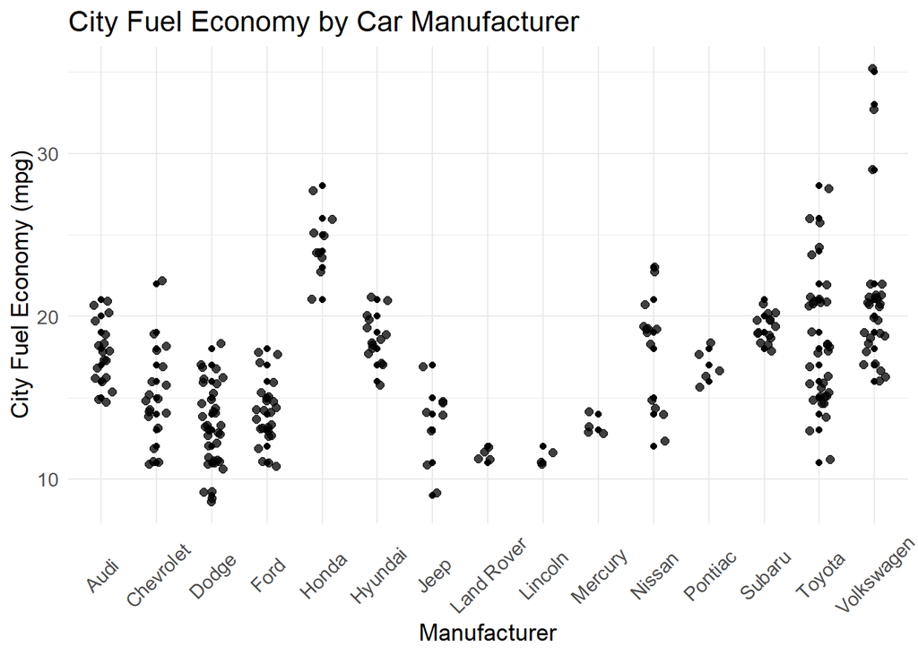

```r
library(tidyverse)
library(ggplot2)

mpg %>%
  mutate(manufacturer = str_to_title(manufacturer)) %>% #Changes to title case
  ggplot2::ggplot(aes(x=manufacturer, y=cty)) +
  geom_jitter(width = .2, alpha = .75, size = 2) +
  geom_point() +
  theme_minimal() +
  theme(axis.text.x=element_text(angle=45, vjust=0.5, hjust=.5)) +
  theme(text = element_text(size = 13)) +
  labs(title = "City Fuel Economy by Car Manufacturer",
       x = "Manufacturer",
       y = "City Fuel Economy (mpg)")
```

### Improving the plot

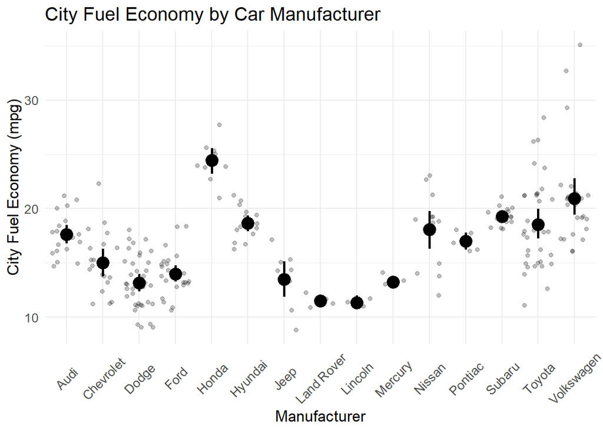

```r
library(Hmisc)

mpg %>%
  mutate(manufacturer = str_to_title(manufacturer)) %>% #Changes to title case
  ggplot2::ggplot(aes(x=manufacturer, y=cty)) +
  stat_summary(fun.data = mean_cl_boot, colour = "black", size = 1) +
  geom_jitter(alpha = .25) +
  theme_minimal() +
  theme(axis.text.x=element_text(angle=45, vjust=0.5, hjust=.5)) +
  theme(text = element_text(size = 13)) +
  labs(title = "City Fuel Economy by Car Manufacturer",
       x = "Manufacturer",
       y = "City Fuel Economy (mpg)")
```

### The finished plot?

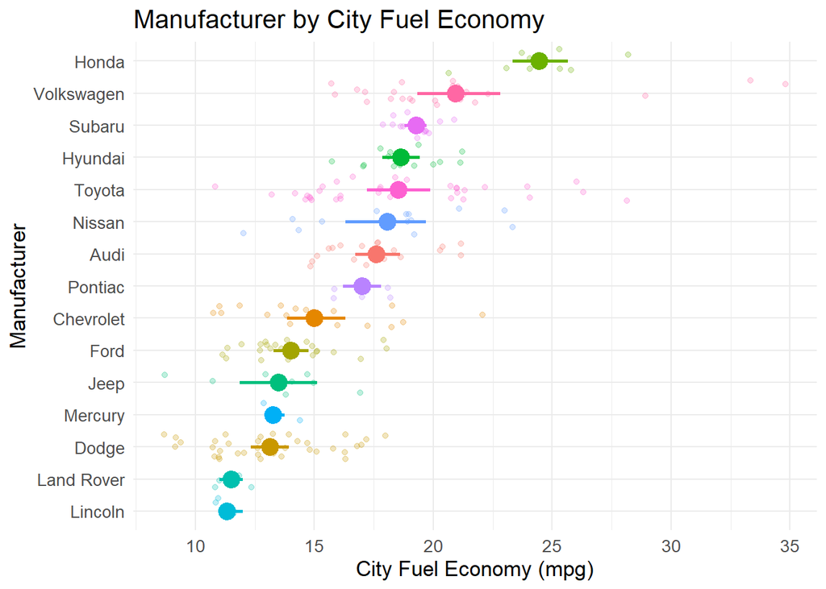

```r
mpg %>%
  mutate(manufacturer = str_to_title(manufacturer)) %>%
  ggplot(aes(x = fct_reorder(manufacturer, .fun = mean, cty), y = cty, colour = manufacturer)) +
  stat_summary(fun.data = mean_cl_boot, size = 1) +
  geom_jitter(alpha = .25) +
  theme_minimal() +
  theme(text = element_text(size = 13)) +
  labs(title = "Manufacturer by City Fuel Economy",
       x = "Manufacturer",
       y = "City Fuel Economy (mpg)") +
  guides(colour = FALSE) +
  coord_flip()
```

### Using `facet_wrap()`

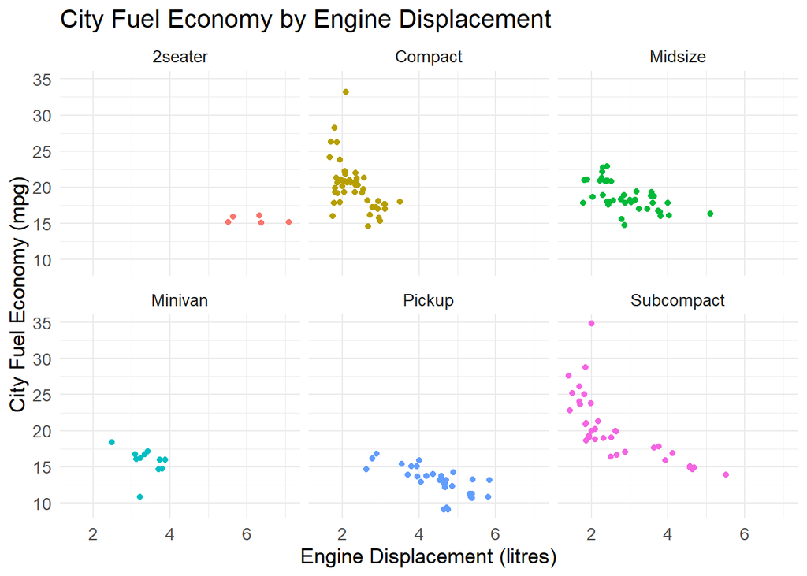

```r
mpg %>%
  filter(class != "suv") %>%
  mutate(class = str_to_title(class)) %>%
  ggplot(aes(x = displ, y = cty, colour = class)) +
  geom_jitter(width = .2) +
  theme_minimal() +
  theme(text = element_text(size = 13)) +
  labs(title = "City Fuel Economy by Engine Displacement",
       x = "Engine Displacement (litres)",
       y = "City Fuel Economy (mpg)") +
  guides(colour = FALSE) +
  facet_wrap(~ class)
```

### Scatterplots

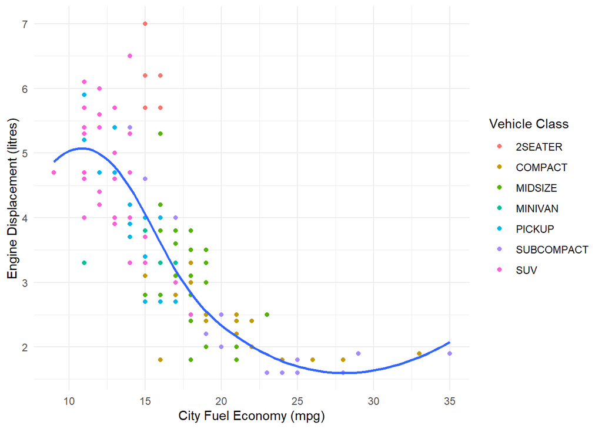

```r
mpg %>%
  mutate(class = str_to_upper(class)) %>%
  ggplot(aes(x = cty, y = displ)) +
  geom_point(aes(colour = class)) +
  geom_smooth(se = FALSE) +
  theme(text = element_text(size = 13)) +
  theme_minimal() +
  labs(x = "City Fuel Economy (mpg)",
       y = "Engine Displacement (litres)",
       colour = "Vehicle Class")
```

### Plotting with histograms

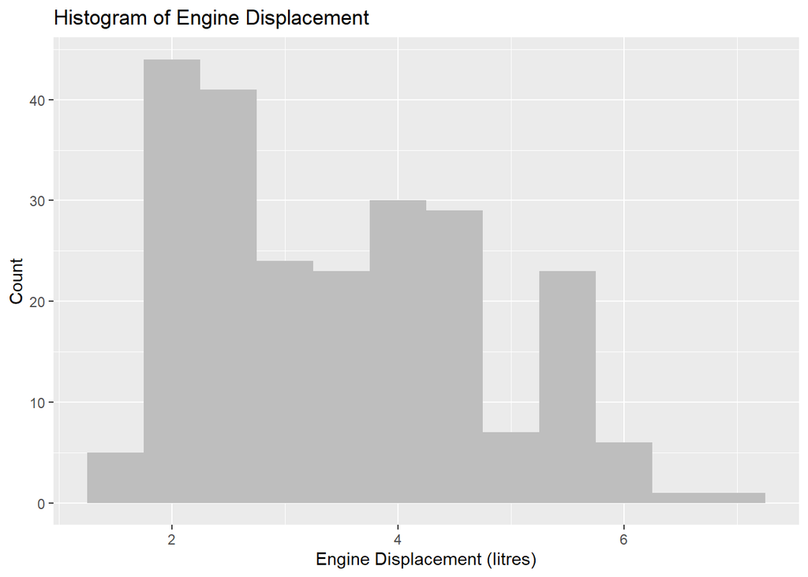

```r
mpg %>%
  ggplot(aes(x = displ)) +
  geom_histogram(binwidth = .5, fill = "grey") +
  labs(title = "Histogram of Engine Displacement",
       x = "Engine Displacement (litres)",
       y = "Count")
```

### The ggridges package

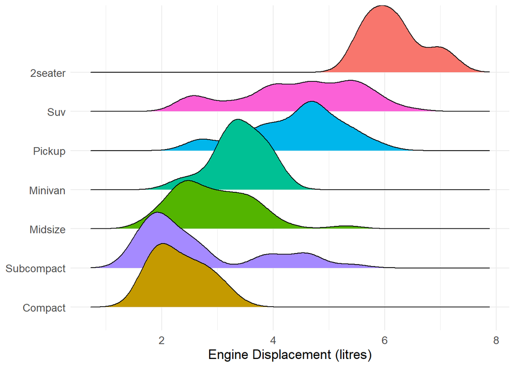

```r
library(ggridges)

mpg %>%
  mutate(class = str_to_title(class)) %>%
  ggplot(aes(x = displ, y = fct_reorder(class, .fun = mean, displ))) +
  geom_density_ridges(height = .5, aes(fill = class)) +
  theme_minimal() +
  theme(text = element_text(size = 13)) +
  guides(fill = FALSE) +
  labs(x = "Engine Displacement (litres)",
       y = NULL)
```

### The `NHANES` dataset

```r
library(NHANES)

ncol(NHANES)
```

```
## [1] 76
```

```r
nrow(NHANES)
```

```
## [1] 10000
```

```r
NHANES %>%
  select(ID) %>%
  n_distinct()
```

```
## [1] 6779
```

To remove duplicates…

```r
NHANES_tidied <- NHANES %>%
  distinct(ID, .keep_all = TRUE)

ncol(NHANES_tidied)
```

```
## [1] 76
```

```r
nrow(NHANES_tidied)
```

```
## [1] 6779
```

Plotting a histogram…

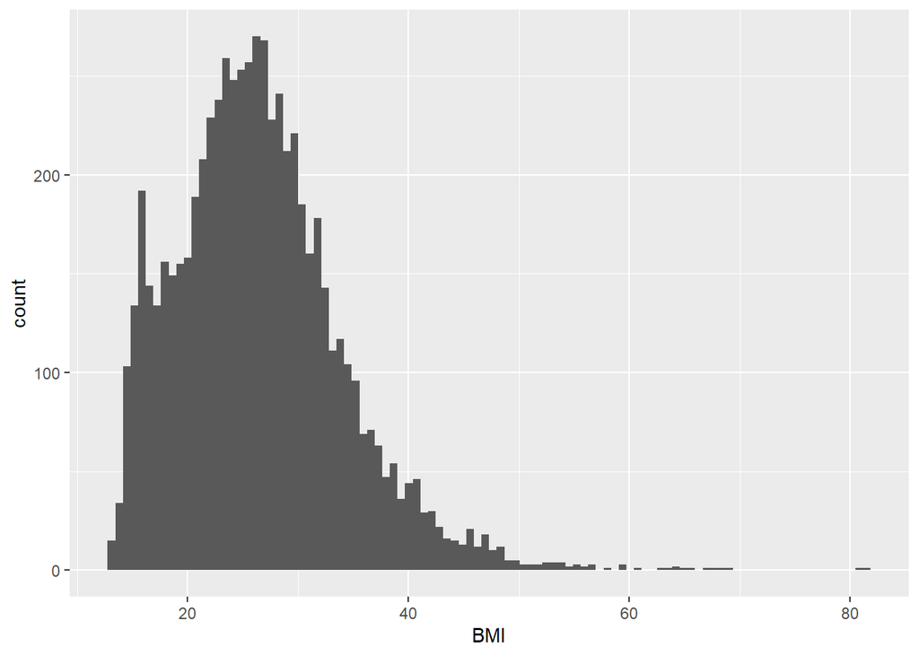

```r
NHANES_tidied %>%
  ggplot(aes(x = BMI)) +
  geom_histogram(bins = 100, na.rm = TRUE)
```

Summary statistics…

```r
NHANES_tidied %>%
  group_by(Education) %>%
  summarise(median = median(BMI, na.rm = TRUE))
```

```
## # A tibble: 6 x 2
##   Education      median
##   <fct>           <dbl>
## 1 8th Grade        28.6
## 2 9 - 11th Grade   28.2
## 3 High School      28.2
## 4 Some College     28.4
## 5 College Grad     26.5
## 6 <NA>             18.9
```

`geom_violin`

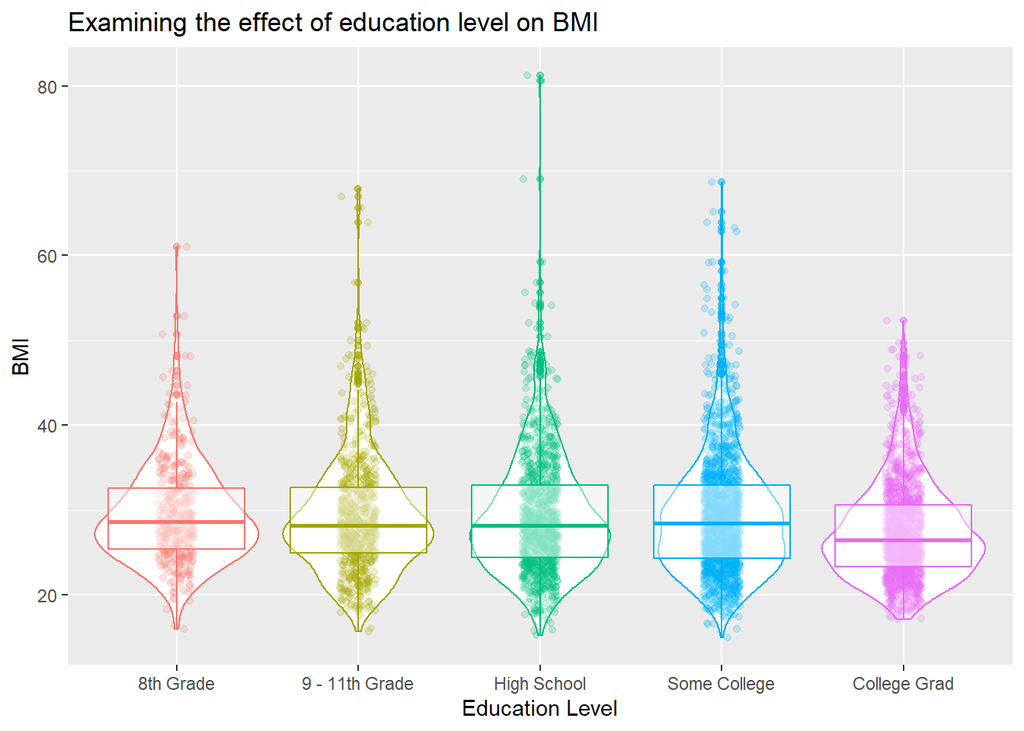

```r
NHANES_tidied %>%
  filter(!is.na(Education) & !is.na(BMI)) %>%
  ggplot(aes(x = Education, y = BMI, colour = Education)) +
  geom_violin() +
  geom_jitter(alpha = .2, width = .1) +
  geom_boxplot(alpha = .5) +
  guides(colour = FALSE) +
  labs(title = "Examining the effect of education level on BMI",
       x = "Education Level",
       y = "BMI")
```

Plotting interaction effects…

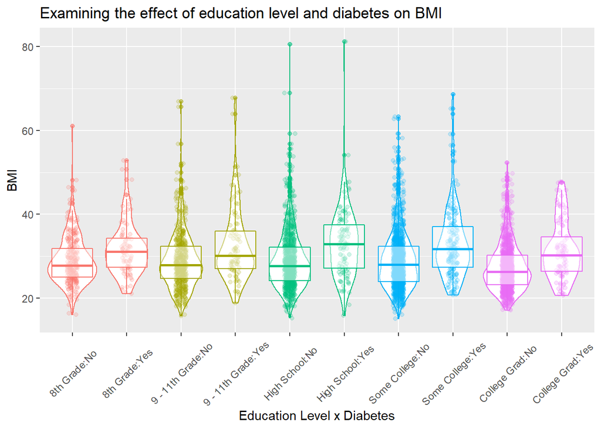

```r
NHANES_tidied %>%
  filter(!is.na(Education) & !is.na(BMI) & !is.na(Diabetes)) %>%
  ggplot(aes(x = Education:Diabetes, y = BMI, colour = Education)) +
  geom_violin() +
  geom_jitter(alpha = .2, width = .1) +
  geom_boxplot(alpha = .5) +
  guides(colour = FALSE) +
  theme(axis.text.x = element_text(angle = 45, vjust = 0.5)) +
  labs(title = "Examining the effect of education level and diabetes on BMI",
       x = "Education Level x Diabetes",
       y = "BMI")
```

Histograms with `facet_wrap()`

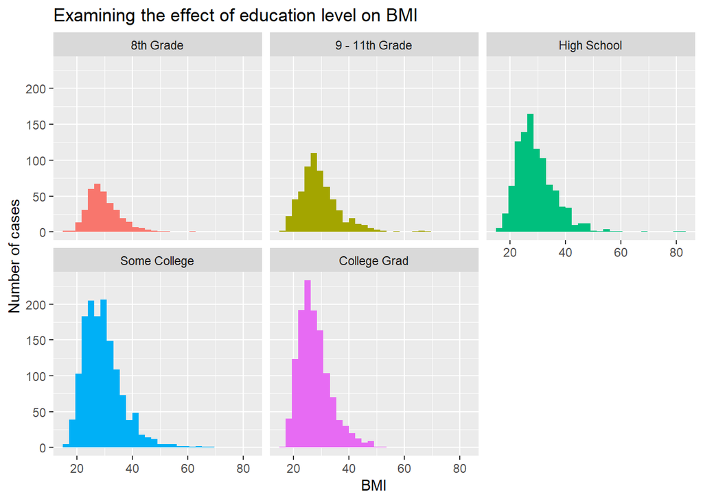

```r
NHANES_tidied %>%
  filter(!is.na(Education) & !is.na(BMI)) %>%
  group_by(Education) %>%
  ggplot(aes(x = BMI, fill = Education)) +
  geom_histogram() +
  guides(fill = FALSE) +
  labs(title = "Examining the effect of education level on BMI",
       x = "BMI",
       y = "Number of cases") +
  facet_wrap(~ Education)
```

Density function…

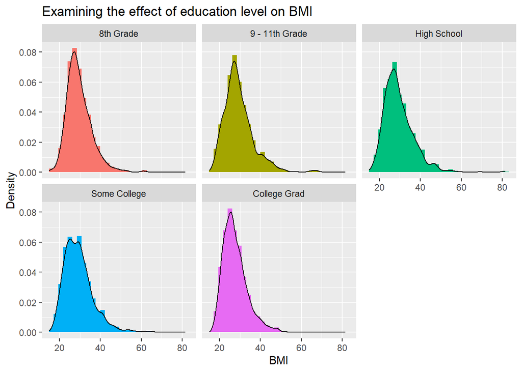

```r
NHANES_tidied %>%
  filter(!is.na(Education) & !is.na(BMI)) %>%
  group_by(Education) %>%
  ggplot(aes(x = BMI, fill = Education)) +
  geom_histogram(aes(y = ..density..)) +
  geom_density(aes(y = ..density..)) +
  guides(fill = FALSE) +
  labs( title = "Examining the effect of education level on BMI",
        x = "BMI",
        y = "Density") +
  facet_wrap(~ Education)
```

## Workshop 5 - Regression (Part 1) ——————————————–

### Revision

**Parametric statistics** assume that sample data comes from a population that can be adequately modelled by a probability distribution that has a fixed set of parameters.

Assumptions of parametric statistics: (1) residuals are normally distributed (2) homogeneity of variance (3) Interval data (4) Independence

**Variance** is the measure of the amount by which data associated with a variable vary from the mean of that variable.

If two variables **covary**, then when one variable deviates from the mean, we expect the other variable to deviate from its mean in a similar way.

**Pearson’s product-moment correlation** (Pearson’s *r*) = covariance result / (SD of V1) x (SD of V2). Pearson’s *r* measured on a scale of -1 to 1. Square Pearson’s *r* to get R<sup>2</sup>. Multiple that value by 100 to get the % of variance explained in one variable by the other.

**Regression** is where we want to predict the value of one variable (outcome variable) on the basis of one or more predictor variables. Simple regression is where we have one predictor, multiple regression is where we have more than one. One of the most commonly used regression types is **ordinary least squares** (OLS) which works by minimising the distance (deviation) between the observed data and the linear model.

### Plotting a regression line

With OLS regression, we can plot a straight line that minimises the residuals (i.e. the error).

$\beta_{0}$ = intercept (when $x = 0$)  
$\beta$ = gradient of the line  
$Residual_{i}$ - the difference between predicted score and actual score for participant $i$

$$y = \beta_{0} + \beta x_{i}~ + Residual_{i}$$

Comparing mean and regression line the sums of squares. If the SS<sub>M</sub> of a regression model is large, then the regression model is better. If SS<sub>M</sub> small then the regression line not much better model of data than mean.

To calculate the proportion of improvement in prediction by looking at ration of SS<sub>M</sub> to SS<sub>T</sub>. Actually this is R<sup>2</sup>.

$$R^{2} = \frac{SS_{M}}{SS_{T}}$$
…and this is the same *R<sup>2</sup>* that we worked out by squaring the Pearson correlation coefficient.

Can also use the F-ratio using the mean sums of squares.

$$F = \frac{MS_{M}}{MS_{R}}$$
A good model will have large MS<sub>M</sub> and a small MS<sub>R</sub>. In other words, the improvement of the model compare to the mean will be good. The difference between the model and our observed data will be small. If MS<sub>M</sub> is large and MS<sub>R</sub> is small, then *F* will be large. Determine whether *F* value significant by looking up in table. For SS<sub>M</sub> the degrees of freedom = no. of variables in model. For SS<sub>R</sub> = no. of observations - no. of parameters being estimated.

```r
library(tidyverse)
library(Hmisc)
library(performance)
```

```r
crime <- read_csv("https://raw.githubusercontent.com/ajstewartlang/09_glm_regression_pt1/master/data/crime_dataset.csv")
head(crime)
```

```
## # A tibble: 6 x 9
##    Year index_nsa `City, State` Population `Violent Crimes` Homicides Rapes
##   <dbl>     <dbl> <chr>              <dbl>            <dbl>     <dbl> <dbl>
## 1  1975      41.1 Atlanta, GA       490584             8033       185   443
## 2  1975      30.8 Chicago, IL      3150000            37160       818  1657
## 3  1975      36.4 Cleveland, OH     659931            10403       288   491
## 4  1975      20.9 Oakland, CA       337748             5900       111   316
## 5  1975      20.4 Seattle, WA       503500             3971        52   324
## 6    NA      NA   <NA>                  NA               NA        NA    NA
## # ... with 2 more variables: Assaults <dbl>, Robberies <dbl>
```

Tidy the data…

```r
crime <- separate(crime, col = "City, State", into = c("City", "State"))
head(crime)
```

```
## # A tibble: 6 x 10
##    Year index_nsa City      State Population `Violent Crimes` Homicides Rapes
##   <dbl>     <dbl> <chr>     <chr>      <dbl>            <dbl>     <dbl> <dbl>
## 1  1975      41.1 Atlanta   GA        490584             8033       185   443
## 2  1975      30.8 Chicago   IL       3150000            37160       818  1657
## 3  1975      36.4 Cleveland OH        659931            10403       288   491
## 4  1975      20.9 Oakland   CA        337748             5900       111   316
## 5  1975      20.4 Seattle   WA        503500             3971        52   324
## 6    NA      NA   <NA>      <NA>          NA               NA        NA    NA
## # ... with 2 more variables: Assaults <dbl>, Robberies <dbl>
```

```r
crime <- crime %>%
  rename(House_price = index_nsa) %>%
  rename(Violent_Crimes = "Violent Crimes")
head(crime)
```

```
## # A tibble: 6 x 10
##    Year House_price City      State Population Violent_Crimes Homicides Rapes
##   <dbl>       <dbl> <chr>     <chr>      <dbl>          <dbl>     <dbl> <dbl>
## 1  1975        41.1 Atlanta   GA        490584           8033       185   443
## 2  1975        30.8 Chicago   IL       3150000          37160       818  1657
## 3  1975        36.4 Cleveland OH        659931          10403       288   491
## 4  1975        20.9 Oakland   CA        337748           5900       111   316
## 5  1975        20.4 Seattle   WA        503500           3971        52   324
## 6    NA        NA   <NA>      <NA>          NA             NA        NA    NA
## # ... with 2 more variables: Assaults <dbl>, Robberies <dbl>
```

Building a plot…

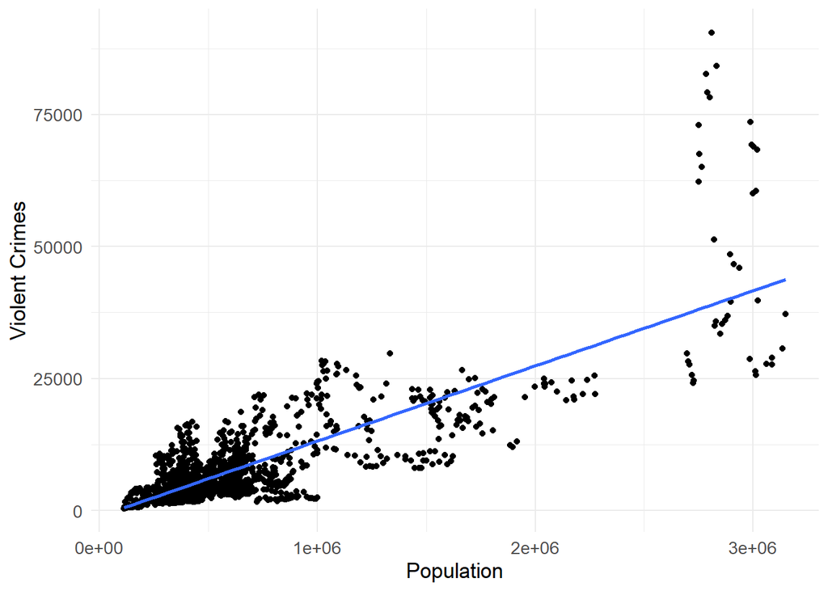

```r
crime %>%
  ggplot(aes(x = Population, y = Violent_Crimes)) +
  geom_point() +
  geom_smooth(method = "lm", se = FALSE) +
  theme_minimal() +
  theme(text = element_text(size = 13)) +
  labs(x = "Population",
       y = "Violent Crimes")
```

Pearson’s R…

```r
rcorr(crime$Population, crime$Violent_Crimes)
```

```
##      x    y
## x 1.00 0.81
## y 0.81 1.00
##
## n
##      x    y
## x 1714 1708
## y 1708 1708
##
## P
##   x  y
## x     0
## y  0
```

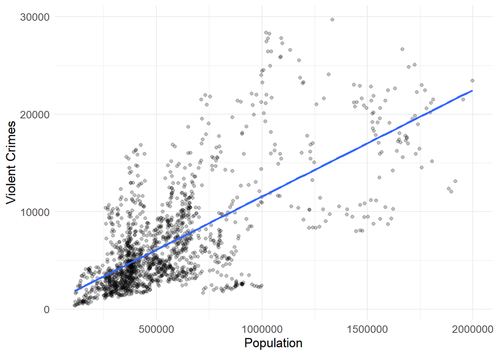

```r
crime_filtered <- filter(crime, Population < 2000000)
crime_filtered %>%
  ggplot(aes(x = Population, y = Violent_Crimes)) +
  geom_point(alpha = .25) +
  geom_smooth(method = "lm", se = FALSE) +
  theme_minimal() +
  theme(text = element_text(size = 13)) +
  labs(x = "Population",
       y = "Violent Crimes")
```

```r
rcorr(crime_filtered$Population, crime_filtered$Violent_Crimes)
```

```
##      x    y
## x 1.00 0.69
## y 0.69 1.00
##
## n
##      x    y
## x 1659 1653
## y 1653 1653
##
## P
##   x  y
## x     0
## y  0
```

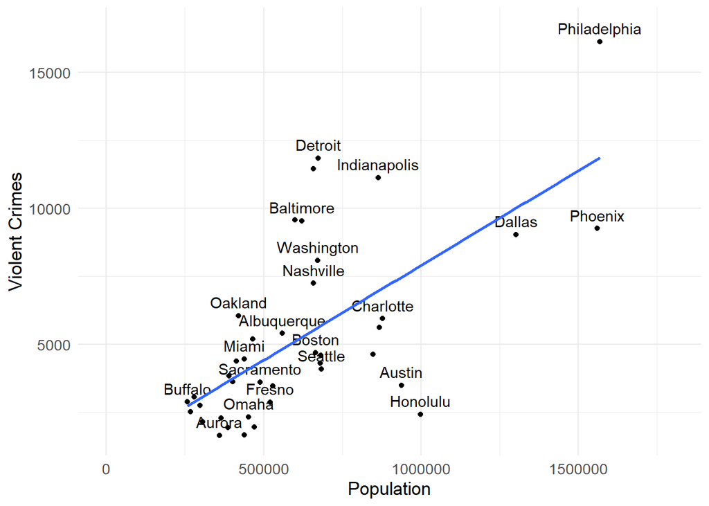

```r
crime_filtered <- filter(crime_filtered, Year == 2015)
crime_filtered %>%
  ggplot(aes(x = Population, y = Violent_Crimes, label = City)) +
  geom_point() +
  geom_text(nudge_y = 500, check_overlap = TRUE) +
  geom_smooth(method = "lm", se = FALSE) +
  xlim(0, 1800000) +
  theme_minimal() +
  theme(text = element_text(size = 13)) +
  labs(x = "Population",
       y = "Violent Crimes")
```

```r
rcorr(crime_filtered$Population, crime_filtered$Violent_Crimes)
```

```
##      x    y
## x 1.00 0.65
## y 0.65 1.00
##
## n
##    x  y
## x 42 40
## y 40 40
##
## P
##   x  y
## x     0
## y  0
```

Model the data…

```r
model1 <- lm(Violent_Crimes ~ 1, data = crime_filtered)
model2 <- lm(Violent_Crimes ~ Population, data = crime_filtered)
```

Checking our assumptions…

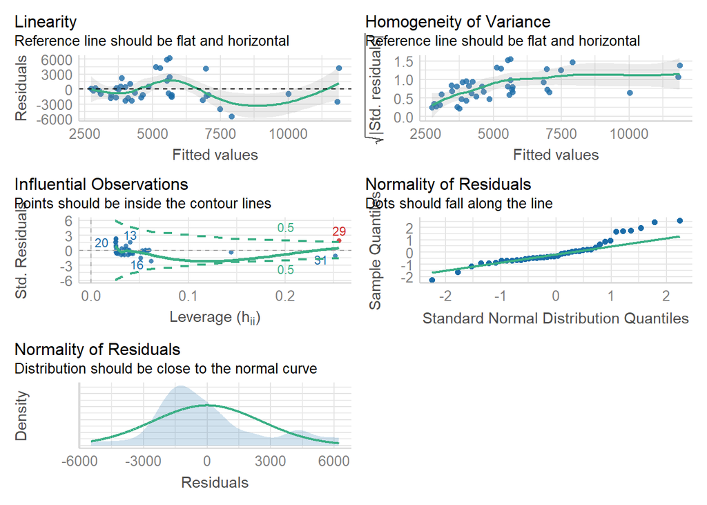

```r
check_model(model2)
```

```r
anova(model1, model2)
```

```
## Analysis of Variance Table
##
## Model 1: Violent_Crimes ~ 1
## Model 2: Violent_Crimes ~ Population
##   Res.Df       RSS Df Sum of Sq      F    Pr(>F)
## 1     39 445568991
## 2     38 257690819  1 187878173 27.705 5.813e-06 ***
## ---
## Signif. codes:  0 '***' 0.001 '**' 0.01 '*' 0.05 '.' 0.1 ' ' 1
```

Interpreting our model…

```r
summary(model2)
```

```
##
## Call:
## lm(formula = Violent_Crimes ~ Population, data = crime_filtered)
##
## Residuals:
##     Min      1Q  Median      3Q     Max
## -5465.8 -1633.4  -809.1   684.3  6213.8
##
## Coefficients:
##              Estimate Std. Error t value Pr(>|t|)
## (Intercept) 9.443e+02  9.216e+02   1.025    0.312
## Population  6.963e-03  1.323e-03   5.264 5.81e-06 ***
## ---
## Signif. codes:  0 '***' 0.001 '**' 0.01 '*' 0.05 '.' 0.1 ' ' 1
##
## Residual standard error: 2604 on 38 degrees of freedom
##   (2 observations deleted due to missingness)
## Multiple R-squared:  0.4217, Adjusted R-squared:  0.4064
## F-statistic: 27.71 on 1 and 38 DF,  p-value: 5.813e-06
```

The intercept corresponds to where our regression line intercepts the y-axis, and the Population parameter corresponds to the slope of our line. We see that for every increase in population by 1 there is an extra 0.006963 increase in violent crime.

For a city with a population of about a million, there will be about 7907 Violent Crimes. We calculate this by multiplying the estimate of our predictor (0.006963) by 1,000,000 and then adding the intercept (944.3). This gives us 7907.3 crimes - which tallys with what you see in our regression line above. We may have a few outliers - how would you figure out what those were? Try excluding any outliers you find and re-building your model.

## Workshop 6 - Regression (Part 2) ——————————————–

### Considerations

- Sample size - do we have enough **power** to detect our minimal effect size of interest?
- Do we need to worry about issue related **multicollinearity** and **singularity**?
- Ensure our residuals are approximately normal - and the way don’t have any issues around **skewness**, **non-linearity** or **homoscedasticity**. Do we have any **outliers** of influential cases?

### How big an ‘N’?

Use data simulation, but rule of thumb… - For testing the regression model, N > 49 + 8k (where k = no. of predictors) - For testing individual predictors, N > 103 + k (choose the one the produces the greater number)

### Multicollinearity and singularity

Multicollinearity: where two or more variables are highly correlated, tested by examining **Variance Inflation Factor (VIF)** value for each variable. Use `vif()` function in the `car` package in R. A VIF factor of >10 suggests a multicollinearity issue (although >5 has been suggested to).

Singularity: redundancy, e.g. one of the variables is a combination of two or more of the other IVs.

We use collinearity diagnostics to see if we have a problem.

### Assumptions

#### Normality

For every predicted score, the observed score around that prediction should be normally distributed. Can be investigated using a **Q-Q plot** (expect a straight diagonal line).

#### Linearity

Relationship to be modelled must be linear. That is, an increase in the scores of the predictor should be followed by an increase in the outcome and vice versa.

There must be a uniform relationship between the fitted values and the residual error that can be captured by a straight line.

Minor violation of this assumption is not dire - it weakens the power of the analysis to capture the relationship between the variables.

#### Homoscedasticity

SDs of errors of predictions should be approximately equal for all predicted scores. That is, the amount of error is the same at different predicted balues of the outcome.

Violation is not terminal, but does weaken the analysis.

Can be corrected by using weighted (generalised) least squares regression instead of OLS regression.

#### Outliers

Outliers are cases that don’t fit model well - have large residuals. Like correlation, regression models are sensitive to outliers so it makes sense to remove them to improve the model. But a bit of a judgement call - they may be theoretically interesting.

Influential cases can be detected easily via **Cook’s distance** (part of our diagnostic plots) using the `performance` package.

### The linear model with multiple predictors

```r
MRes_tut2 <- read.csv("https://raw.githubusercontent.com/ajstewartlang/10_glm_regression_pt2/master/data/MRes_tut2.csv") # using read_csv here gave an error
```

```r
library(tidyverse) # Load the tidyverse packages
library(Hmisc) # Needed for correlation
library(MASS) # Needed for maths functions
library(car) # Needed for VIF calculation
library(olsrr) # Needed for stepwise regression
library(performance) # Needed to check model assumptions
```

### Examing possible relationships

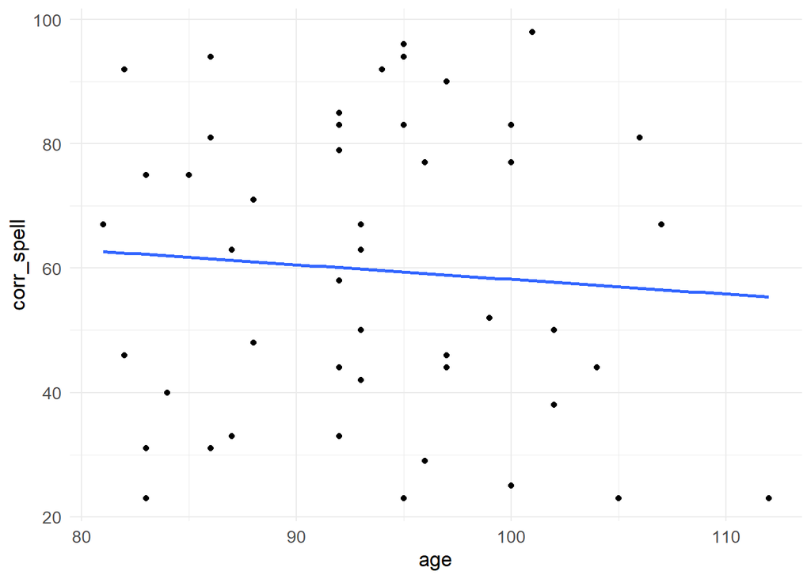

```r
ggplot(MRes_tut2, aes(x = age, y = corr_spell)) +
  geom_point() +
  geom_smooth(method = "lm", se = FALSE) +
  theme_minimal() +
  theme(text = element_text(size = 13))
```

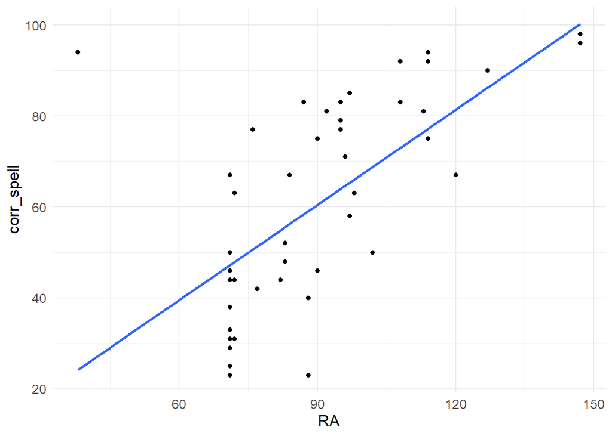

```r
ggplot(MRes_tut2, aes(x = RA, y = corr_spell)) +
  geom_point() +
  geom_smooth(method = "lm", se = FALSE) +
  theme_minimal() +
  theme(text = element_text(size = 13))
```

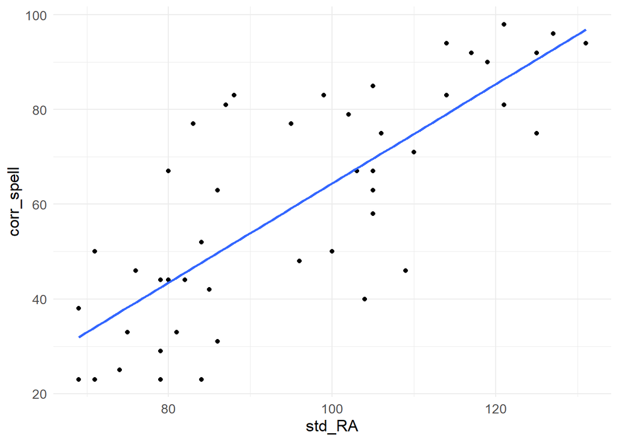

```r
ggplot(MRes_tut2, aes(x = std_RA, y = corr_spell)) +
  geom_point() +
  geom_smooth(method = "lm", se = FALSE) +
  theme_minimal() +
  theme(text = element_text(size = 13))
```

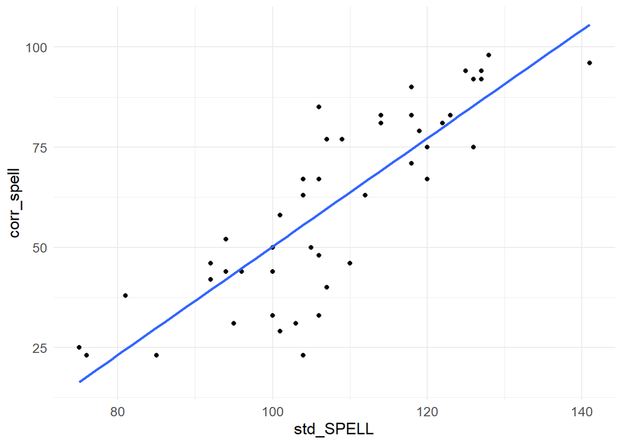

```r
ggplot(MRes_tut2, aes(x = std_SPELL, y = corr_spell)) +
  geom_point() +
  geom_smooth(method = "lm", se = FALSE) +
  theme_minimal() +
  theme(text = element_text(size = 13))
```

### Model the data

We are going to do hierarchical regression first - we’ll build one model (which we’ll call model0) that is the mean of our outcome variable, and another model (model1) which contains all our predictors:

```r
model0 <- lm(corr_spell ~ 1, data = MRes_tut2)
model1 <- lm(corr_spell ~ age + RA + std_RA + std_SPELL, data = MRes_tut2)
```

Compare them…

```r
anova(model0, model1)
```

```
## Analysis of Variance Table
##
## Model 1: corr_spell ~ 1
## Model 2: corr_spell ~ age + RA + std_RA + std_SPELL
##   Res.Df     RSS Df Sum of Sq      F    Pr(>F)
## 1     46 26348.4
## 2     42  3901.1  4     22447 60.417 < 2.2e-16 ***
## ---
## Signif. codes:  0 '***' 0.001 '**' 0.01 '*' 0.05 '.' 0.1 ' ' 1
```

We see that the models differ from each other (look a the p-value of the comparison) and that the model with the four predictors has the lower Residuals (RSS) value meaning there is less error between the model and the observed data relative to the simpler intercept-only model (i.e., the mean) and the observed data.

### Checking our assumptions

OK, so they differ - now let’s plot information about our model assumptions - remember, we are particularly interested in Cook’s distance values for our case…

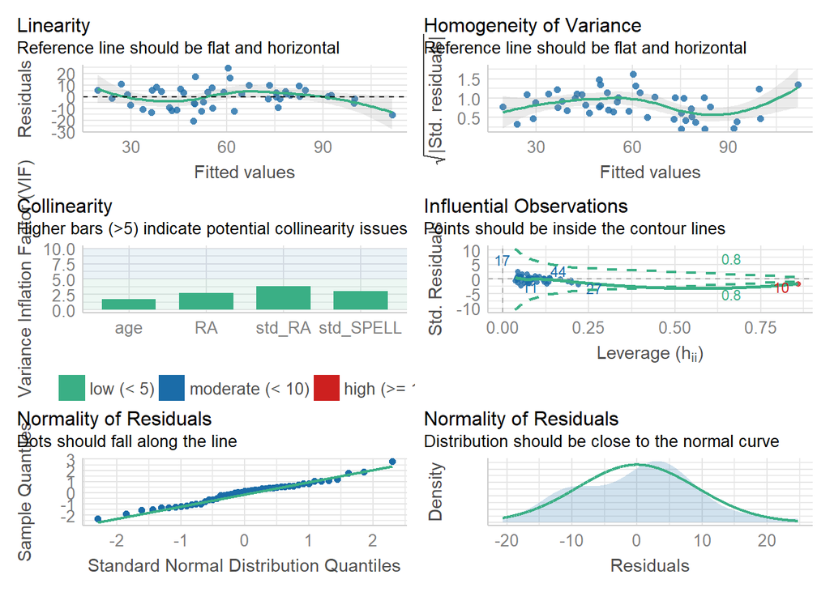

```r
check_model(model1)
```

The errors looks fairly equally distributed along our fitted values (homoscedasticity) - although a little worse for high fitted values - and from the Q-Q plot we can tell they look fairly normal (they should follow the diagonal). How about influential cases? So, Case 10 looks a bit dodgy - it has a high Cook’s Distance value - which suggests it is having a disproportionate effect on our model. Let’s exclude it using the filter() function - the symbol != means ‘does not equal’ so we are selecting values other than Case 10.

Dropping an influential case…

```r
MRes_tut2_drop10 <- filter(MRes_tut2, case != "10")
```

Remodel that data…

We now create another model (`model2`) which doesn’t include Case 10.

```r
model2 <- lm(corr_spell ~ age + RA + std_RA + std_SPELL, data = MRes_tut2_drop10)
```

Let’s check the model assumptions again using `check_model()`.

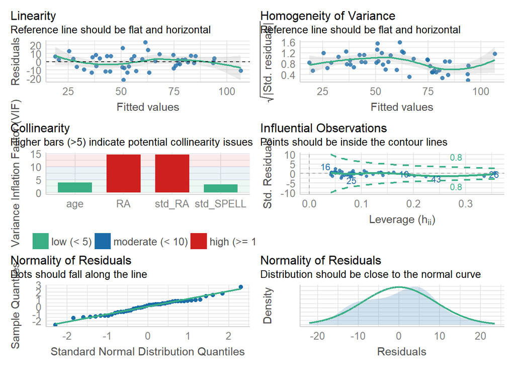

```r
check_model(model2)
```

Now, let’s look at the multicollinearity values measured by VIF:

```r
vif(model2)
```

```
##       age        RA    std_RA std_SPELL
##  3.843462 14.763168 14.672084  3.140457
```

It looks like RA and std_RA are problematic. We can look at the correlation between them using the `rcorr()` function:

```r
rcorr(MRes_tut2_drop10$RA, MRes_tut2_drop10$std_RA)
```

```
##      x    y
## x 1.00 0.88
## y 0.88 1.00
##
## n= 46
##
##
## P
##   x  y
## x     0
## y  0
```

Remodel the data…

The correlation is pretty high (0.88), so let’s exclude the predictor with the highest VIF value (which is RA) and build a new model:

```r
model3 <- lm(corr_spell ~ age + std_RA + std_SPELL, data = MRes_tut2_drop10)
vif(model3)
```

```
##       age    std_RA std_SPELL
##  1.190827  2.636186  2.821235
```

Checking our assumptions…

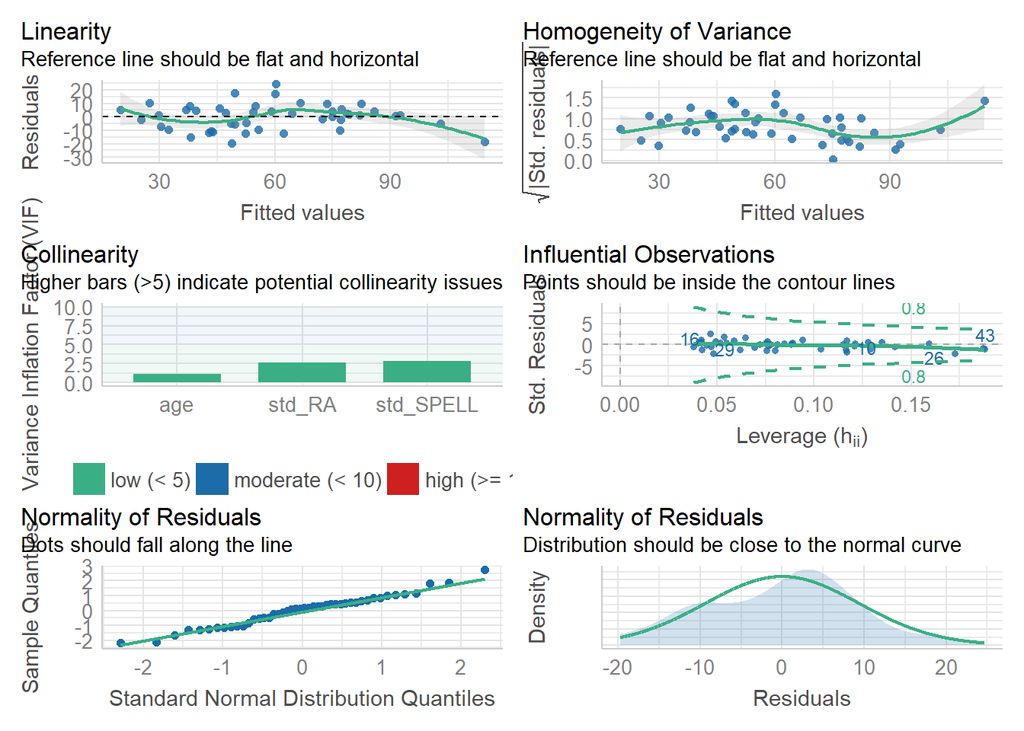

```r
check_model(model3)
```

### Summary of our model

```r
summary(model3)
```

```
##
## Call:
## lm(formula = corr_spell ~ age + std_RA + std_SPELL, data = MRes_tut2_drop10)
##
## Residuals:
##     Min      1Q  Median      3Q     Max
## -19.801  -6.907   1.327   5.155  24.669
##
## Coefficients:
##              Estimate Std. Error t value Pr(>|t|)
## (Intercept) -209.4400    26.7210  -7.838 9.43e-10 ***
## age            1.1033     0.2133   5.172 6.09e-06 ***
## std_RA         0.3804     0.1385   2.747  0.00883 **
## std_SPELL      1.2107     0.1650   7.339 4.78e-09 ***
## ---
## Signif. codes:  0 '***' 0.001 '**' 0.01 '*' 0.05 '.' 0.1 ' ' 1
##
## Residual standard error: 9.824 on 42 degrees of freedom
## Multiple R-squared:  0.8388, Adjusted R-squared:  0.8273
## F-statistic: 72.87 on 3 and 42 DF,  p-value: < 2.2e-16
```

```r
model0 <- lm(corr_spell ~ 1, data = MRes_tut2_drop10)
anova(model3, model0)
```

```
## Analysis of Variance Table
##
## Model 1: corr_spell ~ age + std_RA + std_SPELL
## Model 2: corr_spell ~ 1
##   Res.Df     RSS Df Sum of Sq      F    Pr(>F)
## 1     42  4053.5
## 2     45 25151.0 -3    -21098 72.866 < 2.2e-16 ***
## ---
## Signif. codes:  0 '***' 0.001 '**' 0.01 '*' 0.05 '.' 0.1 ' ' 1
```

We’d write our equation as something like:

`Spelled correct = -209.44 + 1.10(age) + 0.38(std_RA) + 1.21(std_SPELL) + residual`

### Stepwise regression

We can also do stepwise regression - forwards is when you start with the null model and predictors are added until they don’t explain any more variance, backwards is when you start with the full model and remove predictors until removal starts affecting your model’s predictive ability. Let’s keep case 10 dropped and also drop the high VIF predictor (RA). This is handy for models with lots of predictors where the order in sequential regression is not obvious.

Model the data…

```r
model0 <- lm(corr_spell ~ 1, data = MRes_tut2_drop10)
model1 <- lm(corr_spell ~ age + std_RA + std_SPELL, data = MRes_tut2_drop10)
```

Let’s do stepwise forwards…

```r
steplimitsf <- step(model0, scope = list (lower = model0, upper = model1), direction = "forward")
```

```
## Start:  AIC=291.98
## corr_spell ~ 1
##
##             Df Sum of Sq     RSS    AIC
## + std_SPELL  1   17802.2  7348.8 237.39
## + std_RA     1   14780.1 10370.9 253.23
## <none>                   25151.0 291.98
## + age        1      48.7 25102.3 293.89
##
## Step:  AIC=237.39
## corr_spell ~ std_SPELL
##
##          Df Sum of Sq    RSS    AIC
## + age     1   2567.20 4781.6 219.62
## + std_RA  1    714.14 6634.7 234.69
## <none>                7348.8 237.39
##
## Step:  AIC=219.62
## corr_spell ~ std_SPELL + age
##
##          Df Sum of Sq    RSS    AIC
## + std_RA  1     728.1 4053.5 214.02
## <none>                4781.6 219.62
##
## Step:  AIC=214.02
## corr_spell ~ std_SPELL + age + std_RA
```

```r
summary(steplimitsf)
```

```
##
## Call:
## lm(formula = corr_spell ~ std_SPELL + age + std_RA, data = MRes_tut2_drop10)
##
## Residuals:
##     Min      1Q  Median      3Q     Max
## -19.801  -6.907   1.327   5.155  24.669
##
## Coefficients:
##              Estimate Std. Error t value Pr(>|t|)
## (Intercept) -209.4400    26.7210  -7.838 9.43e-10 ***
## std_SPELL      1.2107     0.1650   7.339 4.78e-09 ***
## age            1.1033     0.2133   5.172 6.09e-06 ***
## std_RA         0.3804     0.1385   2.747  0.00883 **
## ---
## Signif. codes:  0 '***' 0.001 '**' 0.01 '*' 0.05 '.' 0.1 ' ' 1
##
## Residual standard error: 9.824 on 42 degrees of freedom
## Multiple R-squared:  0.8388, Adjusted R-squared:  0.8273
## F-statistic: 72.87 on 3 and 42 DF,  p-value: < 2.2e-16
```

Stepwise backwards…

```r
steplimitsb <- step(model1, direction = "back")
```

```
## Start:  AIC=214.02
## corr_spell ~ age + std_RA + std_SPELL
##
##             Df Sum of Sq    RSS    AIC
## <none>                   4053.5 214.02
## - std_RA     1     728.1 4781.6 219.62
## - age        1    2581.2 6634.7 234.69
## - std_SPELL  1    5198.3 9251.8 249.98
```

```r
summary(steplimitsb)
```

```
##
## Call:
## lm(formula = corr_spell ~ age + std_RA + std_SPELL, data = MRes_tut2_drop10)
##
## Residuals:
##     Min      1Q  Median      3Q     Max
## -19.801  -6.907   1.327   5.155  24.669
##
## Coefficients:
##              Estimate Std. Error t value Pr(>|t|)
## (Intercept) -209.4400    26.7210  -7.838 9.43e-10 ***
## age            1.1033     0.2133   5.172 6.09e-06 ***
## std_RA         0.3804     0.1385   2.747  0.00883 **
## std_SPELL      1.2107     0.1650   7.339 4.78e-09 ***
## ---
## Signif. codes:  0 '***' 0.001 '**' 0.01 '*' 0.05 '.' 0.1 ' ' 1
##
## Residual standard error: 9.824 on 42 degrees of freedom
## Multiple R-squared:  0.8388, Adjusted R-squared:  0.8273
## F-statistic: 72.87 on 3 and 42 DF,  p-value: < 2.2e-16
```

And stepwise using both forwards and backwards procedures:

```r
steplimitsboth <- step(model0, scope = list (upper = model1), direction = "both")
```

```
## Start:  AIC=291.98
## corr_spell ~ 1
##
##             Df Sum of Sq     RSS    AIC
## + std_SPELL  1   17802.2  7348.8 237.39
## + std_RA     1   14780.1 10370.9 253.23
## <none>                   25151.0 291.98
## + age        1      48.7 25102.3 293.89
##
## Step:  AIC=237.39
## corr_spell ~ std_SPELL
##
##             Df Sum of Sq     RSS    AIC
## + age        1    2567.2  4781.6 219.62
## + std_RA     1     714.1  6634.7 234.69
## <none>                    7348.8 237.39
## - std_SPELL  1   17802.2 25151.0 291.98
##
## Step:  AIC=219.62
## corr_spell ~ std_SPELL + age
##
##             Df Sum of Sq     RSS    AIC
## + std_RA     1     728.1  4053.5 214.02
## <none>                    4781.6 219.62
## - age        1    2567.2  7348.8 237.39
## - std_SPELL  1   20320.7 25102.3 293.89
##
## Step:  AIC=214.02
## corr_spell ~ std_SPELL + age + std_RA
##
##             Df Sum of Sq    RSS    AIC
## <none>                   4053.5 214.02
## - std_RA     1     728.1 4781.6 219.62
## - age        1    2581.2 6634.7 234.69
## - std_SPELL  1    5198.3 9251.8 249.98
```

Checking assumptions…

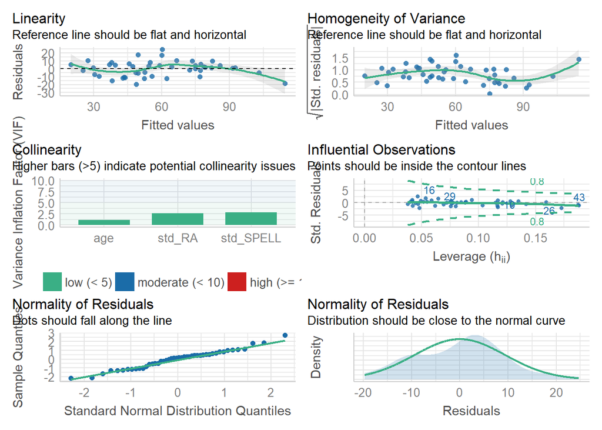

```r
check_model(steplimitsboth)
```

These look ok.

```r
summary(steplimitsboth)
```

```
##
## Call:
## lm(formula = corr_spell ~ std_SPELL + age + std_RA, data = MRes_tut2_drop10)
##
## Residuals:
##     Min      1Q  Median      3Q     Max
## -19.801  -6.907   1.327   5.155  24.669
##
## Coefficients:
##              Estimate Std. Error t value Pr(>|t|)
## (Intercept) -209.4400    26.7210  -7.838 9.43e-10 ***
## std_SPELL      1.2107     0.1650   7.339 4.78e-09 ***
## age            1.1033     0.2133   5.172 6.09e-06 ***
## std_RA         0.3804     0.1385   2.747  0.00883 **
## ---
## Signif. codes:  0 '***' 0.001 '**' 0.01 '*' 0.05 '.' 0.1 ' ' 1
##
## Residual standard error: 9.824 on 42 degrees of freedom
## Multiple R-squared:  0.8388, Adjusted R-squared:  0.8273
## F-statistic: 72.87 on 3 and 42 DF,  p-value: < 2.2e-16
```

You’ll see that the same final model is arrived it in each case. We have three significant predictors.

### Entering predictors based on their p-values

We can also use the `ols_step_forward_p()` function from the package `olsrr` - this works by finding the best model by entering the predictors based on their p values. There are other methods within the `olsrr` package. To see them, type `olsrr::` into the console window.

```r
pmodel <- ols_step_forward_p(model1)
pmodel
```

```
##
##                              Selection Summary
## ---------------------------------------------------------------------------
##         Variable                   Adj.
## Step     Entered     R-Square    R-Square     C(p)        AIC        RMSE
## ---------------------------------------------------------------------------
##    1    std_SPELL      0.7078      0.7012    34.1439    369.9304    12.9236
##    2    age            0.8099      0.8010     9.5442    352.1614    10.5452
##    3    std_RA         0.8388      0.8273     4.0000    346.5624     9.8241
## ---------------------------------------------------------------------------
```

## Workshop 8 - ANOVA (Part 1) ————————————————-

### Inroduction

This is known as the **familywise error rate**, or, 1-(0.95)<sup>n</sup>

*t*-tests tell us whether or not two samples have statistically indistinguishable means. ANOVA tells us whether two or more samples have statistically indistinguishable means. As the *t*-test produces the *t*-statistic, the ANOVA gives us an F-statistic or F-ratio which compares the amount of systematic variance in our data with the amount of unsystematic variance.